# Data Analysis and Visualization in R - CaseStudy I

Ganesh Chandrasekaran, Chandramohan Sudar, Mohammad Shaukat, Aditi Deshpande

11 Dezember 2019

# Add libraries

```r
library(stringr) # String operations
library(chron) # Time operations
library(ggplot2) # Plotting
library(plyr) # Data Manipulation
library(dplyr) # Splitting Applying Combining Data
library(tidyverse) #Melting purpose
library(reshape2)
library(data.table) # for setDT
```

# Read the datasets

```r
airlines_df <- read.csv("../datasets/airlines.csv")
airports_df <- read.csv("../datasets/airports.csv")
flights_df <- read.csv("../datasets/flightsLAX.csv")
```

# Print flights_df

```
##   YEAR MONTH DAY DAY_OF_WEEK AIRLINE FLIGHT_NUMBER TAIL_NUMBER
## 1 2015     1   1           4      AA          2336      N3KUAA
## 2 2015     1   1           4      AA           258      N3HYAA
## 3 2015     1   1           4      US          2013      N584UW
## 4 2015     1   1           4      DL          1434      N547US
## 5 2015     1   1           4      AA           115      N3CTAA
## 6 2015     1   1           4      UA          1545      N76517
##   ORIGIN_AIRPORT DESTINATION_AIRPORT SCHEDULED_DEPARTURE DEPARTURE_TIME
## 1            LAX                 PBI                  10              2
## 2            LAX                 MIA                  20             15
## 3            LAX                 CLT                  30             44
## 4            LAX                 MSP                  35             35
## 5            LAX                 MIA                 105            103
## 6            LAX                 IAH                 115            112
##   DEPARTURE_DELAY TAXI_OUT WHEELS_OFF SCHEDULED_TIME ELAPSED_TIME AIR_TIME
```

[output cut: 27 more lines]

# Data Cleaning: Convert time columns to the time format

Use pad and gsub to convert the time columns to correct time format

# Print cleaned flights_df

```
##   YEAR MONTH DAY DAY_OF_WEEK AIRLINE FLIGHT_NUMBER TAIL_NUMBER
## 1 2015     1   1           4      AA          2336      N3KUAA
## 2 2015     1   1           4      AA           258      N3HYAA
## 3 2015     1   1           4      US          2013      N584UW
## 4 2015     1   1           4      DL          1434      N547US
## 5 2015     1   1           4      AA           115      N3CTAA
## 6 2015     1   1           4      UA          1545      N76517
##   ORIGIN_AIRPORT DESTINATION_AIRPORT SCHEDULED_DEPARTURE DEPARTURE_TIME
## 1            LAX                 PBI            00:10:00       00:02:00
## 2            LAX                 MIA            00:20:00       00:15:00
## 3            LAX                 CLT            00:30:00       00:44:00
## 4            LAX                 MSP            00:35:00       00:35:00
## 5            LAX                 MIA            01:05:00       01:03:00
## 6            LAX                 IAH            01:15:00       01:12:00
##   DEPARTURE_DELAY TAXI_OUT WHEELS_OFF SCHEDULED_TIME ELAPSED_TIME AIR_TIME
```

[output cut: 27 more lines]

## Traffic Information - Check no. of incoming and outgoing flights from LAX

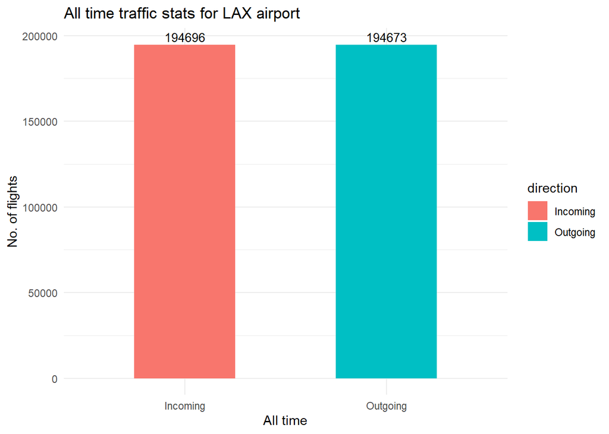

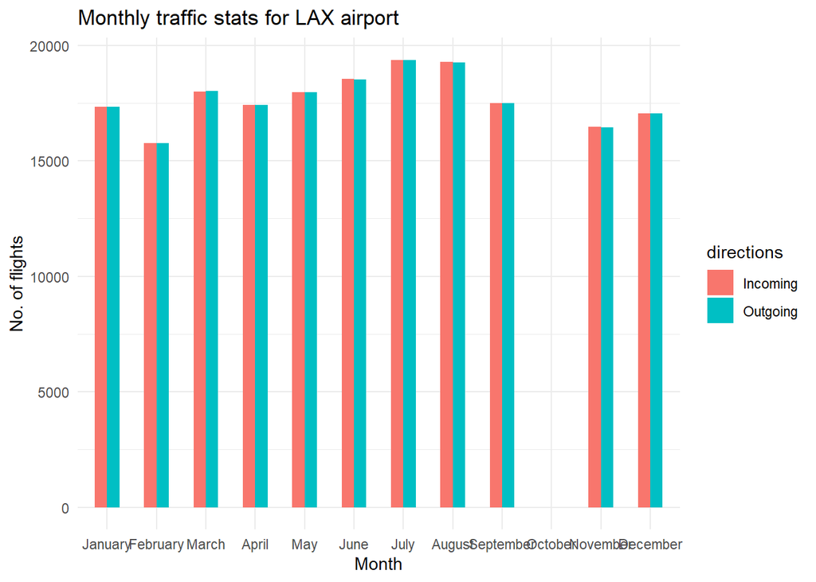

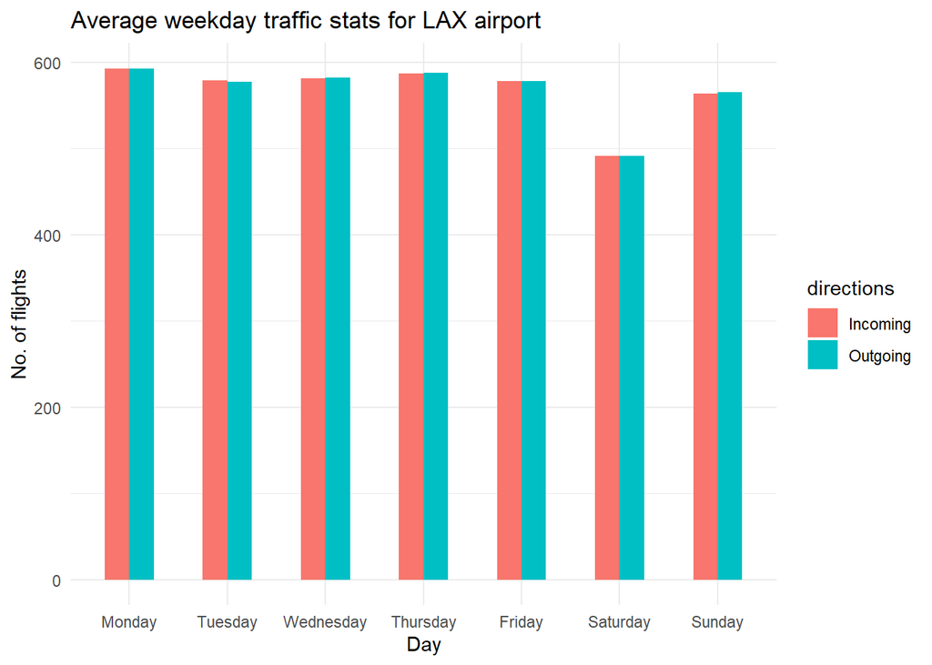

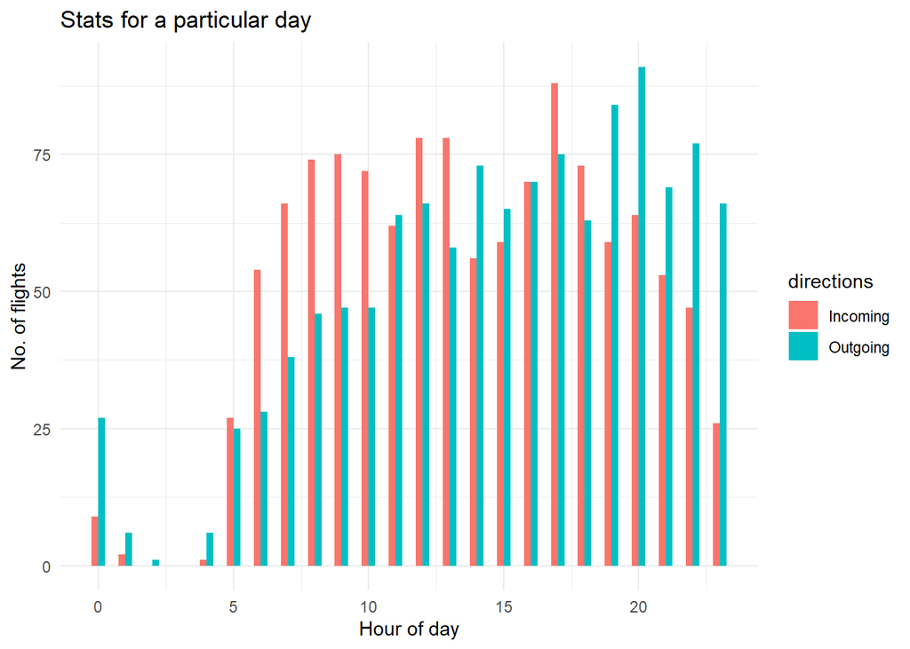

### Line plots of hourly traffic information from Monday-Sunday

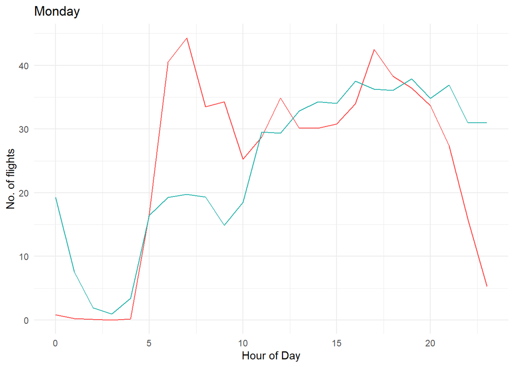

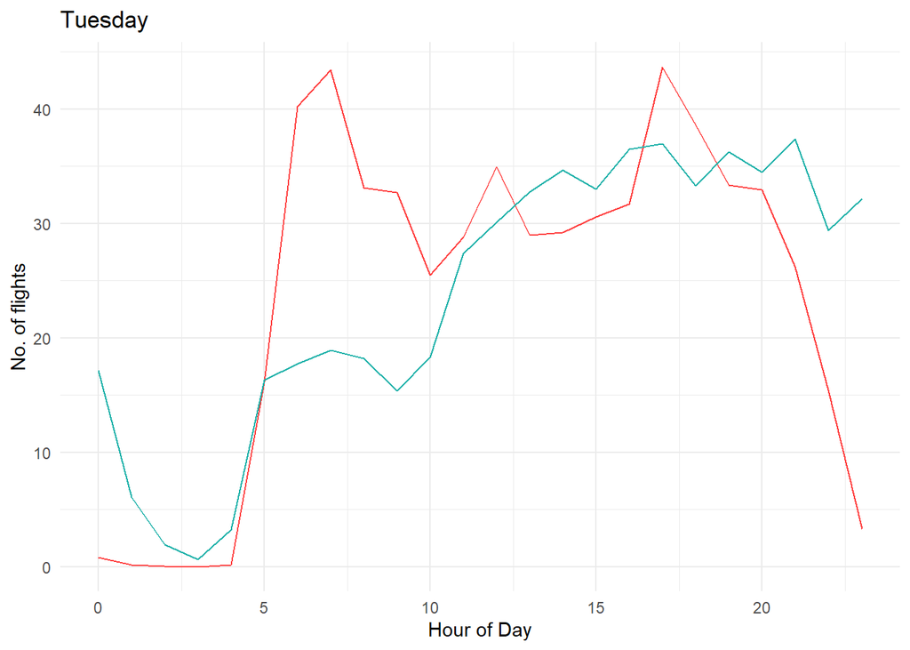

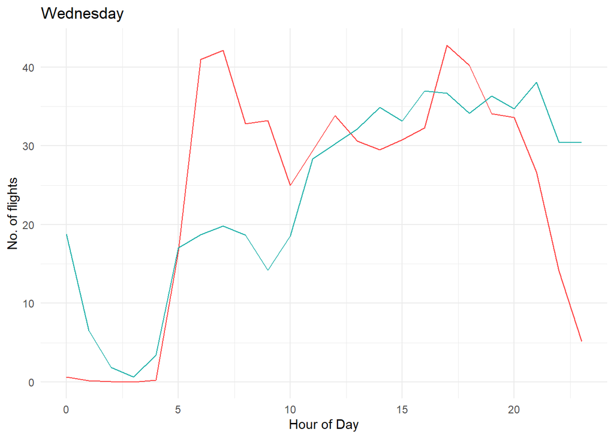

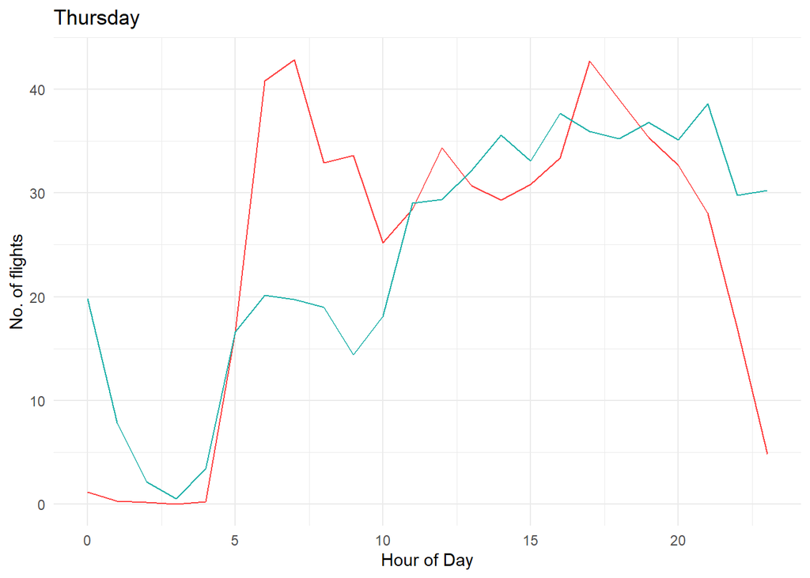

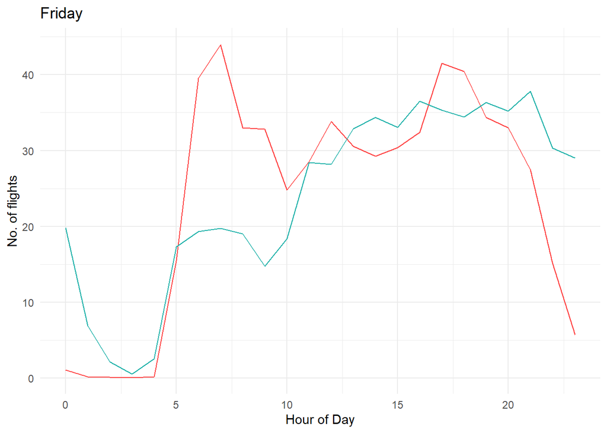

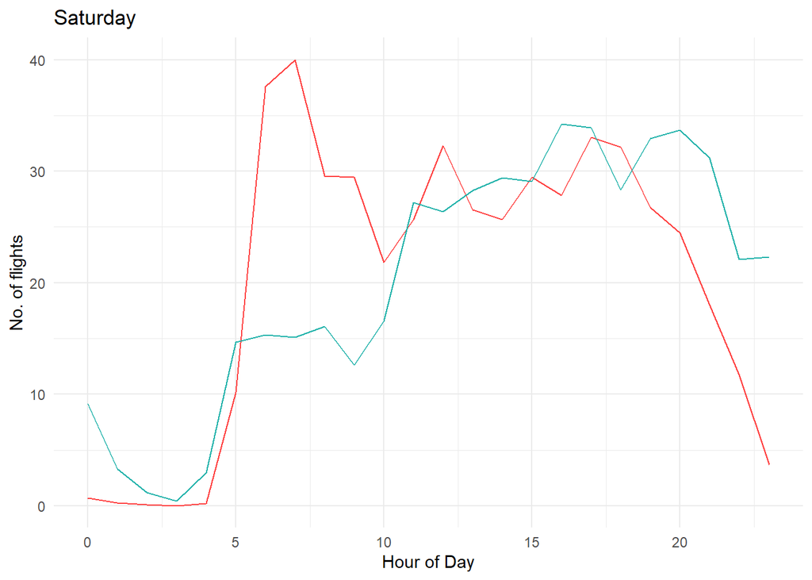

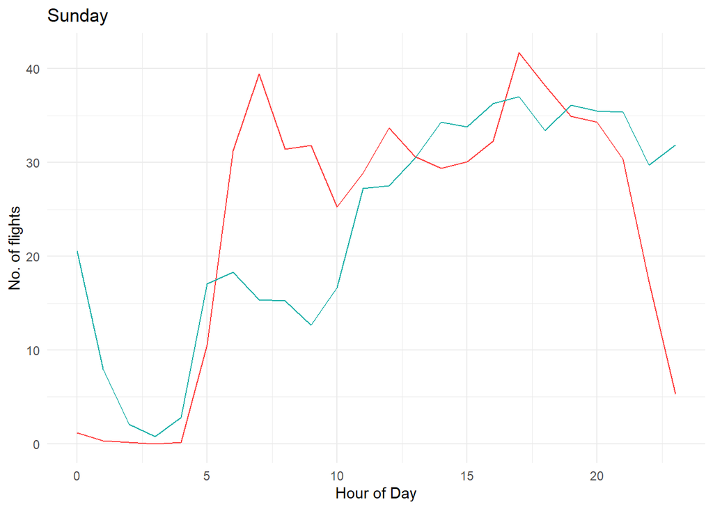

# Cancellation Reason

#### Visualize Flight Cancellation Reason

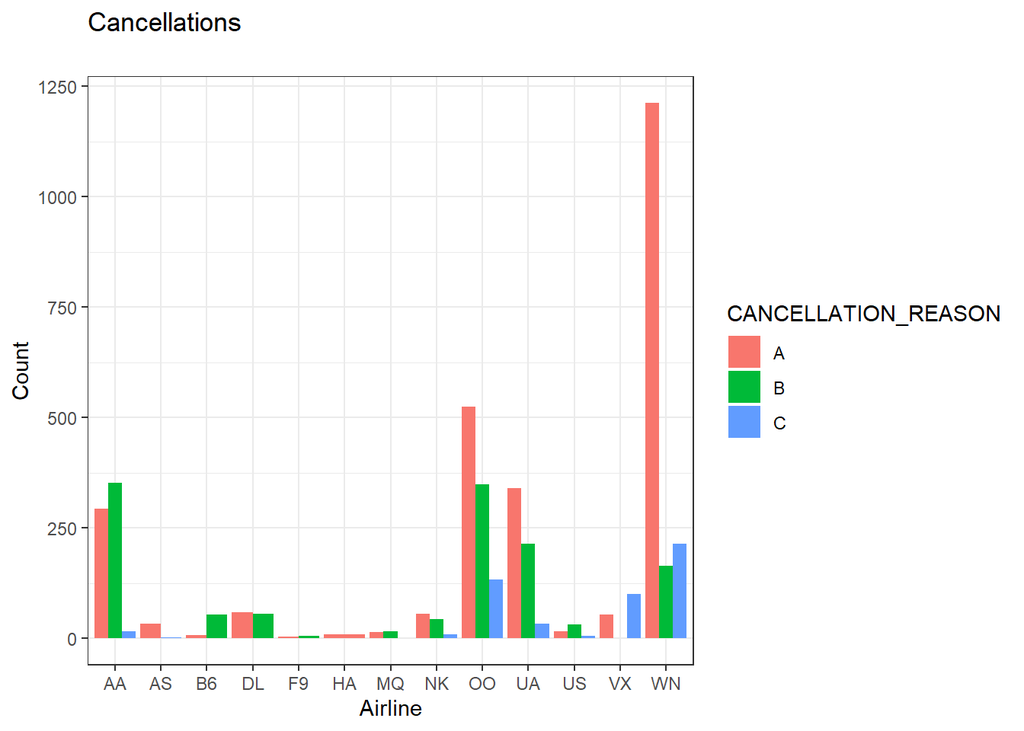

# Analysing Arrival Delay

Variable ‘Arrival Delay’ is directly proportional to [Departure Delay] and delay occured while covering the distance WheelsOFF and WheelsIN.

Its calculated by DELAY_IN_AIR = ELAPSED_TIME - SCHEDULED_TIME

```
##    AIRLINE FLIGHT_NUMBER TAIL_NUMBER DEPARTURE_DELAY DELAY_IN_AIR
## 9       OO          2599      N435SW              73          -17
## 12      AA          2410      N3BAAA              10           -8
## 13      UA          1222      N68452               2            2
## 23      OO          5242      N744SK              39           -9
## 24      OO          5466      N568SW              54           34
## 28      OO          5181      N788SK              -3           12
##    ARRIVAL_DELAY
## 9             56
## 12             2
## 13             4
## 23            30
## 24            88
## 28             9
```

## Calculate the mean of all the delays

```
## # A tibble: 6 x 8
##   AIRLINE Mean_DEPARTURE_~ Mean_ARRIVAL_DE~ Mean_AIR_SYSTEM~
##   <fct>              <dbl>            <dbl>            <dbl>
## 1 AA                  8.76            1.99            14.4
## 2 AS                  2.37           -0.696           18.7
## 3 B6                 10.6             2.31            18.3
## 4 DL                 10.2             3.20            12.7
## 5 F9                 11.7            10.5             24.3
## 6 HA                  2.92           -1.27             0.486
## # ... with 4 more variables: Mean_SECURITY_DELAY <dbl>,
## #   Mean_AIRLINE_DELAY <dbl>, Mean_LATE_AIRCRAFT_DELAY <dbl>,
## #   Mean_WEATHER_DELAY <dbl>
```

## Delay Distribution w.r.t to type of delays of various Airlines

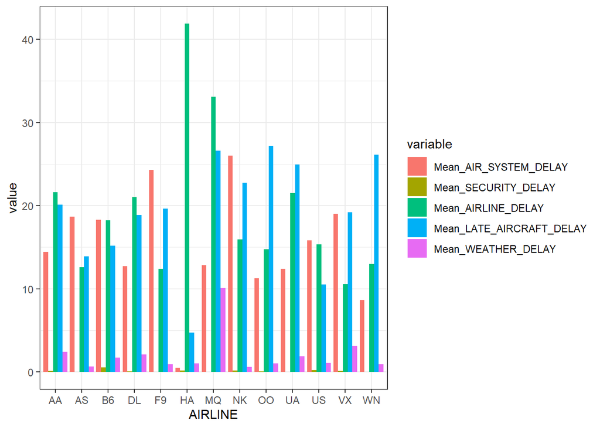

From the above plot, Airline ´HA´ and ´MQ´ are the highest among the AIRLINE DELAY and majority of the delays in Airline ´HA´ is due to Airline Delay.

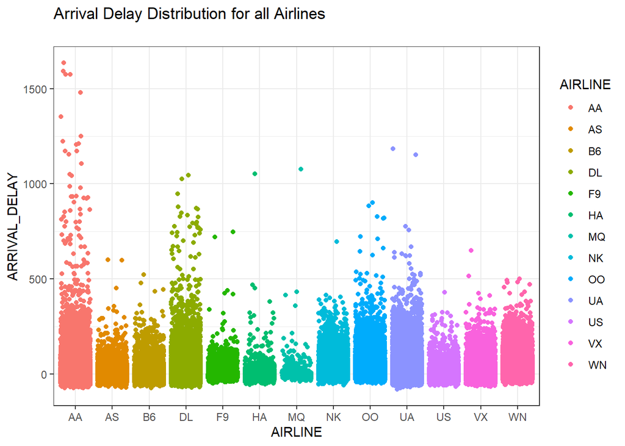

## Pattern of Mean Departure Delay and Arrival Delay of various AIRLINE

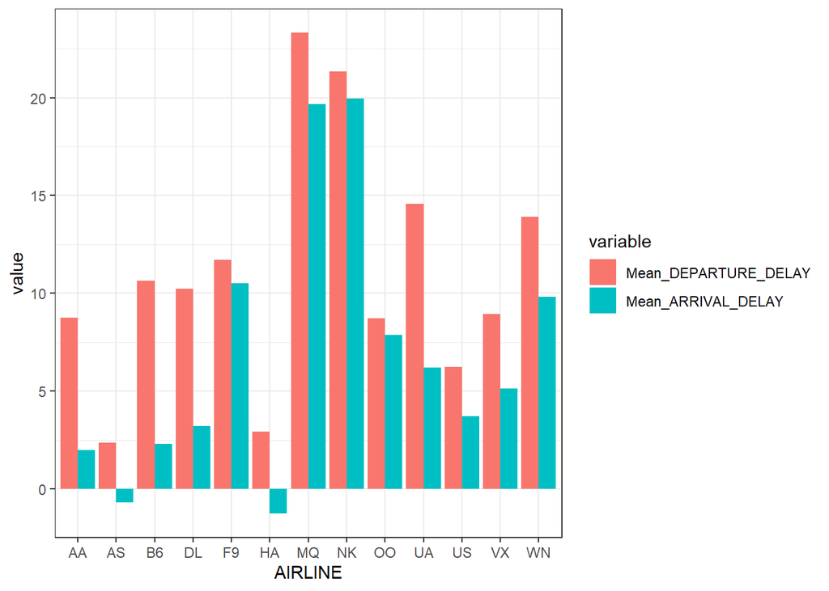

## Analysing Arrival Delay contd.

## ARRIVAL_DELAY

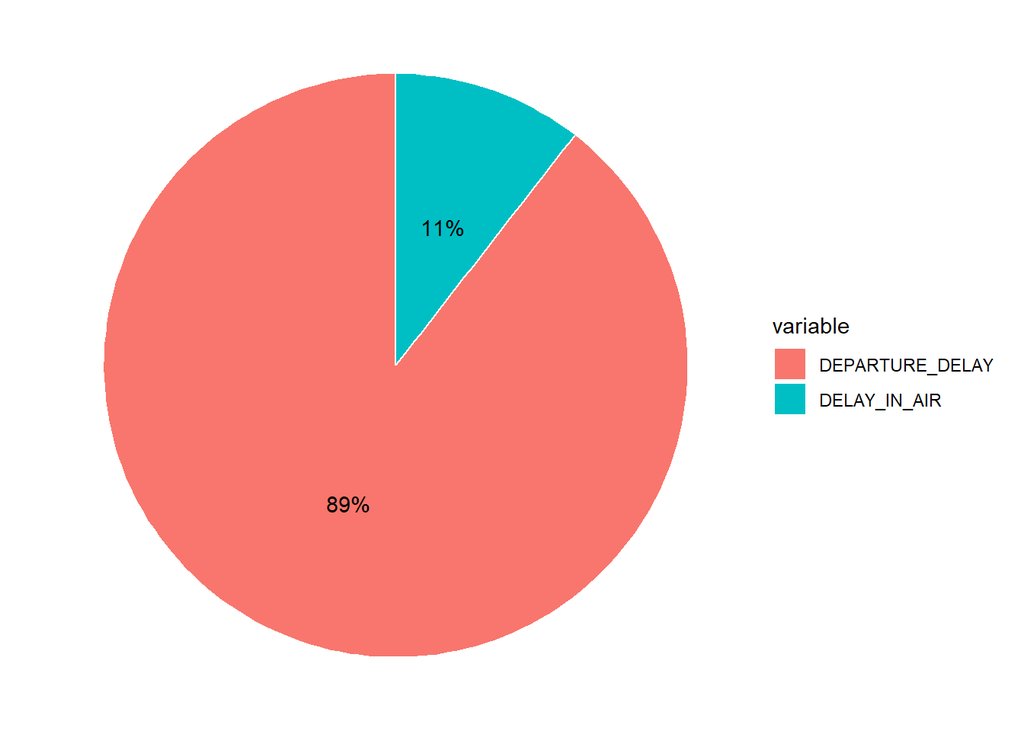

ARRIVAL_DELAY is composed of DEPARTURE_DELAY and DELAY_IN_AIR

Hence from pie chart show that DEPARTURE_DELAY is the major component. Next, we find what leads to DEPARTURE_DELAY and DELAY_IN_AIR.

## Average type of delays

Delays are divided into three categories, namely “on time or small delay” (up to 15 minutes delay), “Medium delay” (15 – 45 minutes delay) and “Large delay” ( 45 minutes delay). In this way the graphic representation is more understandable as well as the possibility of directly comparing the variables related with delays.

## Average type of delays Of various Airline

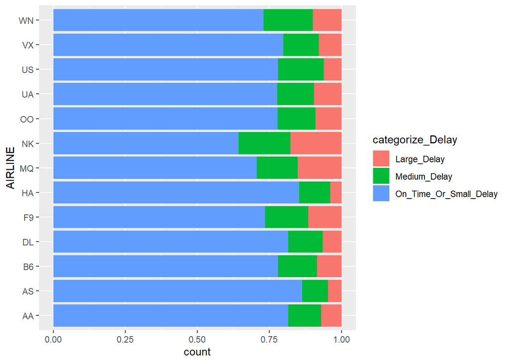

## Airlines cancelled from origin and destination airports

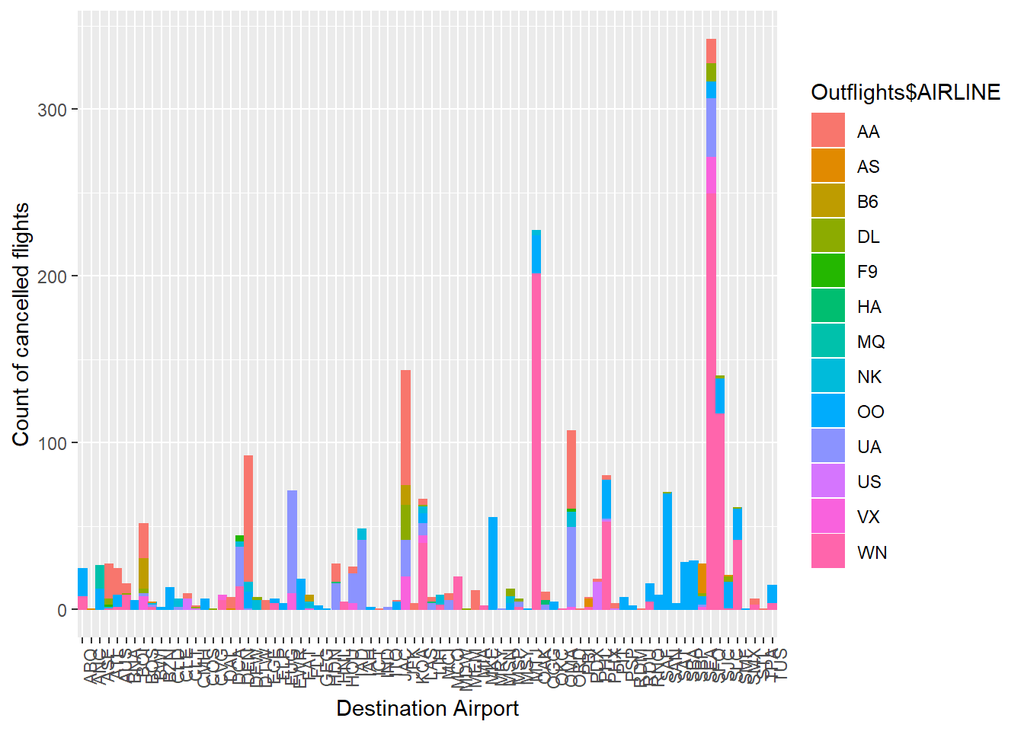

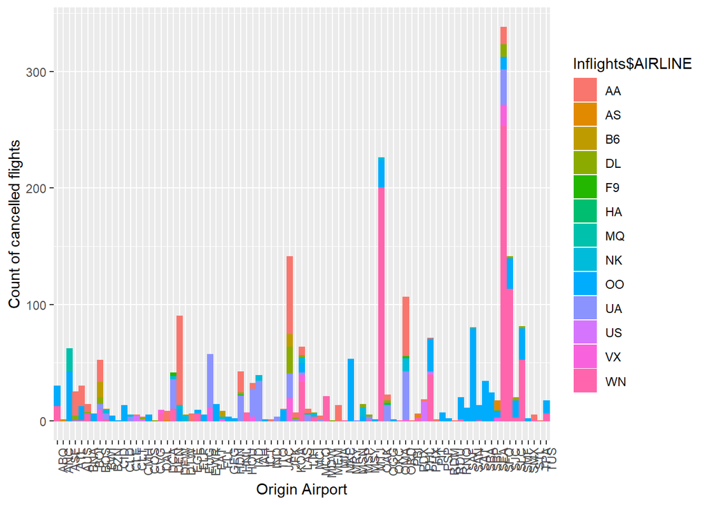

### Now we are checking the top 5 cancellation routes

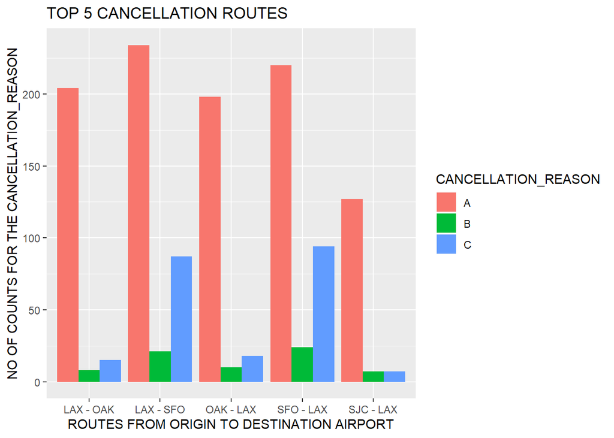

[figure not shown]

# Now we visualize Airline and delay data to find the best and worst performing airline

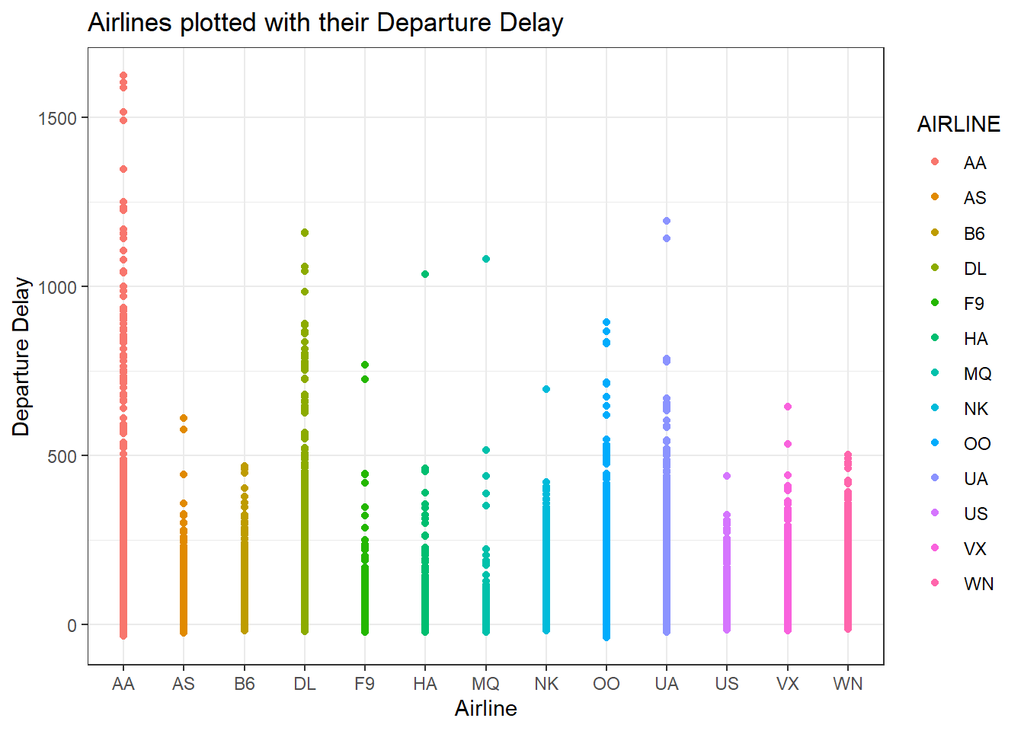

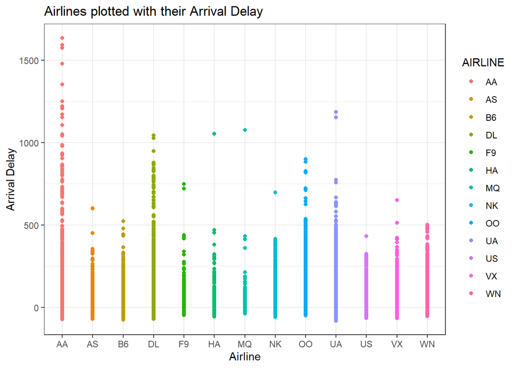

According to these two visualizations,

**Worst Performing Airline:** AA - It consistently delays a lot of its flights and as a result, arrives late at the destination (Arrival_time) (assume that arrival delay is set excluding the time zone variations)

**Best Performing Airline:** MQ – Doesn’t delay a lot of it’s flights and doesn’t have a lot of arrival delays

**But is this a fair comparison?**

### NOT A FAIR COMPARISON – WHY?

This doesn’t seem like to a fair comparison since AA might have been used in a lot of routes whereas MQ might have been used only in a few routes. Our guess turned out to be true.

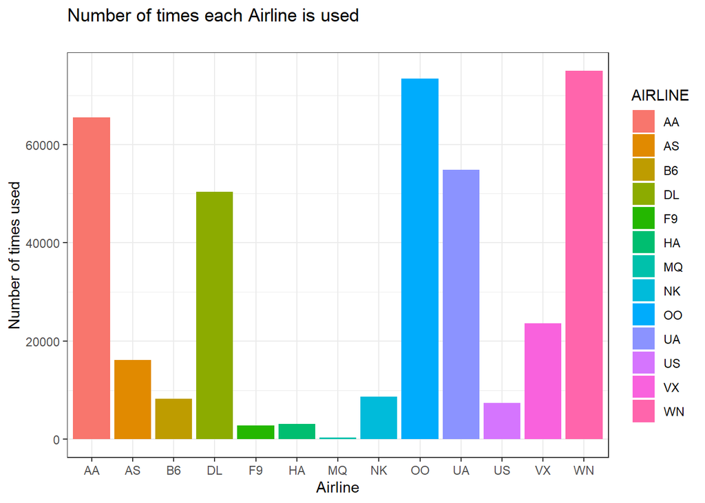

## Count of Airline ‘AA’ and ‘MQ’

```r
count(flights_df %>% group_by(AIRLINE) %>% filter(AIRLINE=="AA"))
```

```
## # A tibble: 1 x 2
## # Groups:   AIRLINE [1]
##   AIRLINE     n
##   <fct>   <int>
## 1 AA      65483
```

```r
count(flights_df %>% group_by(AIRLINE) %>% filter(AIRLINE=="MQ"))
```

```
## # A tibble: 1 x 2
## # Groups:   AIRLINE [1]
##   AIRLINE     n
##   <fct>   <int>
## 1 MQ        368
```

Let’s investigate further into why AA is the worst airline and show that:

# The more the number of busy routes that an airline operates, the worse the airline in terms of delay

First, we find the TOP 10 MOST USED/BUSY routes in the dataset.

find the 161 unique routes between the origin and destination airports and we get the count (number of times) of each unique route being used.

```r
count(flights_df %>% group_by(ORIGIN_AIRPORT,DESTINATION_AIRPORT) %>% filter(ORIGIN_AIRPORT == unique(ORIGIN_AIRPORT) & DESTINATION_AIRPORT == unique(DESTINATION_AIRPORT)))
```

```
## # A tibble: 161 x 3
## # Groups:   ORIGIN_AIRPORT, DESTINATION_AIRPORT [161]
##    ORIGIN_AIRPORT DESTINATION_AIRPORT     n
##    <fct>          <fct>               <int>
##  1 ABQ            LAX                  1834
##  2 ANC            LAX                   382
##  3 ASE            LAX                   774
##  4 ATL            LAX                  5669
##  5 AUS            LAX                  2597
##  6 BNA            LAX                  1637
##  7 BOI            LAX                   682
##  8 BOS            LAX                  4055
##  9 BWI            LAX                  1115
## 10 BZN            LAX                   143
## # ... with 151 more rows
```

Put this into a new data frame named ‘popular_routes’ for easier manipulation

```r
popular_routes <- count(flights_df %>% group_by(ORIGIN_AIRPORT,DESTINATION_AIRPORT) %>% filter(ORIGIN_AIRPORT == unique(ORIGIN_AIRPORT) & DESTINATION_AIRPORT == unique(DESTINATION_AIRPORT)))
```

Merge Origin and Destination column into a new column called ‘Route’ and move it to first

```r
popular_routes$ROUTE <- paste(popular_routes$ORIGIN_AIRPORT,"-",popular_routes$DESTINATION_AIRPORT)
popular_routes$ORIGIN_AIRPORT <- NULL
popular_routes$DESTINATION_AIRPORT <- NULL
popular_routes <- popular_routes[,c(2,1)]
```

We take note of the top 10 most used routes and see that SFO - LAX is the most used route.

```r
head(popular_routes %>% group_by(n) %>% arrange(desc(n)),10)
```

```
## # A tibble: 10 x 2
## # Groups:   n [10]
##    ROUTE         n
##    <chr>     <int>
##  1 SFO - LAX 13744
##  2 LAX - SFO 13457
##  3 JFK - LAX 12016
##  4 LAX - JFK 12015
##  5 LAS - LAX  9715
##  6 LAX - LAS  9594
##  7 LAX - ORD  8256
##  8 ORD - LAX  7941
##  9 SEA - LAX  7765
## 10 LAX - SEA  7732
```

Plot the Top 10 most used routes

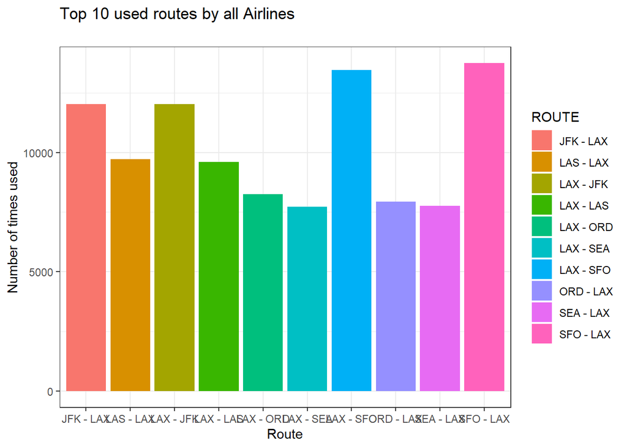

```r
ggplot(head(popular_routes %>% group_by(n) %>% arrange(desc(n)),10), aes(ROUTE,n)) + geom_bar(stat='identity', aes(fill=ROUTE)) + labs(title="Top 10 used routes by all Airlines\n", x="Route",y="Number of times used")+ theme_bw()
```

Now, that we have the top 10 routes, find the unique routes of AA and it’s count

```r
count(flights_df %>% group_by(AIRLINE,ORIGIN_AIRPORT,DESTINATION_AIRPORT) %>% filter(ORIGIN_AIRPORT == unique(ORIGIN_AIRPORT) & DESTINATION_AIRPORT == unique(DESTINATION_AIRPORT) & AIRLINE == "AA"))
```

```
## # A tibble: 60 x 4
## # Groups:   AIRLINE, ORIGIN_AIRPORT, DESTINATION_AIRPORT [60]
##    AIRLINE ORIGIN_AIRPORT DESTINATION_AIRPORT     n
##    <fct>   <fct>          <fct>               <int>
##  1 AA      ATL            LAX                   765
##  2 AA      AUS            LAX                  1242
##  3 AA      BNA            LAX                   621
##  4 AA      BOS            LAX                  1393
##  5 AA      CLT            LAX                   892
##  6 AA      CMH            LAX                   130
##  7 AA      DCA            LAX                   666
##  8 AA      DFW            LAX                  5500
##  9 AA      EGE            LAX                   110
## 10 AA      HNL            LAX                  1342
## # ... with 50 more rows
```

We get 60 unique routes of AA and we find the top 10 most used routes by AA

```r
head(count(flights_df %>% group_by(AIRLINE,ORIGIN_AIRPORT,DESTINATION_AIRPORT) %>% filter(ORIGIN_AIRPORT == unique(ORIGIN_AIRPORT) & DESTINATION_AIRPORT == unique(DESTINATION_AIRPORT) & AIRLINE == "AA")) %>% arrange(desc(n)),10)
```

```
## # A tibble: 10 x 4
## # Groups:   AIRLINE, ORIGIN_AIRPORT, DESTINATION_AIRPORT [10]
##    AIRLINE ORIGIN_AIRPORT DESTINATION_AIRPORT     n
##    <fct>   <fct>          <fct>               <int>
##  1 AA      DFW            LAX                  5500
##  2 AA      LAX            DFW                  5496
##  3 AA      LAX            JFK                  3804
##  4 AA      JFK            LAX                  3803
##  5 AA      LAX            ORD                  3079
##  6 AA      ORD            LAX                  3078
##  7 AA      MIA            LAX                  2652
##  8 AA      LAX            MIA                  2651
##  9 AA      LAS            LAX                  1993
## 10 AA      LAX            LAS                  1993
```

Put this into a new data frame named ‘AA_routes’ for easier manipulation, merge origin and destination column into a new column called ‘Route’ (same as popular_routes df)

```r
AA_routes <- count(flights_df %>% group_by(ORIGIN_AIRPORT,DESTINATION_AIRPORT) %>% filter(ORIGIN_AIRPORT == unique(ORIGIN_AIRPORT) & DESTINATION_AIRPORT == unique(DESTINATION_AIRPORT) & AIRLINE == "AA"))
```

Merge Origin and Destination column into a new column called ‘Route’ and move it to first

```r
AA_routes$ROUTE <- paste(AA_routes$ORIGIN_AIRPORT,"-",AA_routes$DESTINATION_AIRPORT)
AA_routes$ORIGIN_AIRPORT <- NULL
AA_routes$DESTINATION_AIRPORT <- NULL
AA_routes <- AA_routes[,c(2,1)]
```

Plot the Routes for Airline “AA”

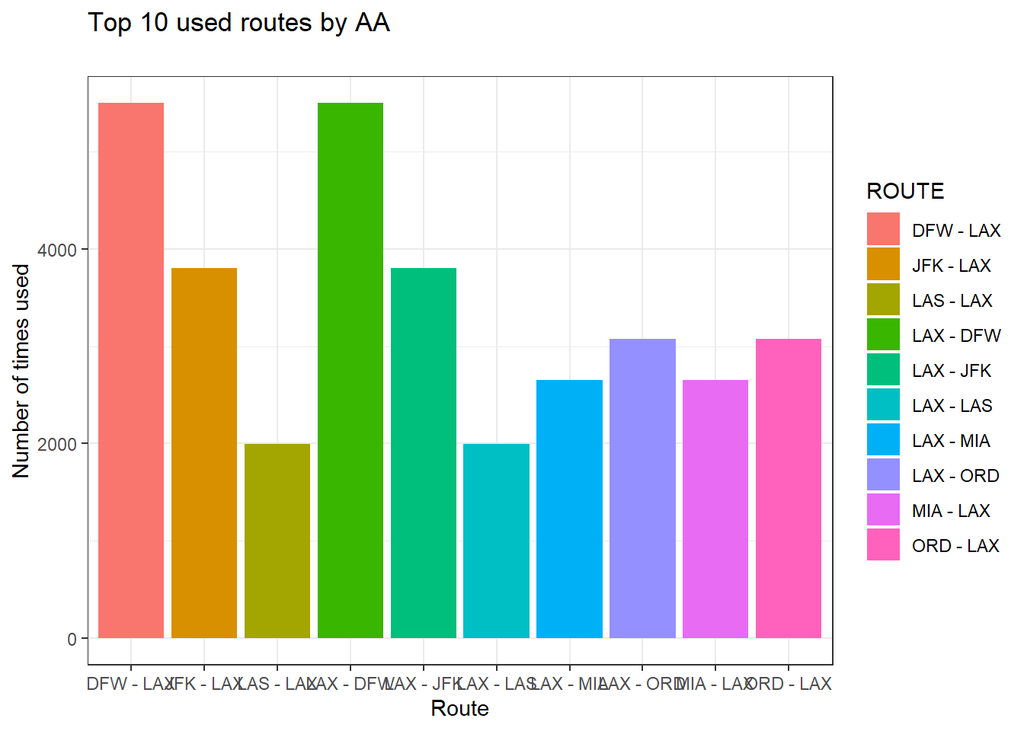

```r
ggplot(head(AA_routes %>% group_by(n) %>% arrange(desc(n)),10), aes(ROUTE,n)) + geom_bar(stat='identity', aes(fill=ROUTE)) + labs(title="Top 10 used routes by AA\n", x="Route",y="Number of times used")+ theme_bw()
```

We can infer from 2 plots that 6 of the top 10 most used routes by AA is the same as the top 10 most used routes by all airlines. So, AA runs on busy routes and this causes delay in it’s flights due to other factors like the number of passengers etc.

# Also, ‘The Busier the route, the more the Delay’

### Data Manipulation:

Find the mean average and departure delay for each unique route in the dataset

Merge the origin and destination airport columns to get the ‘ROUTE’ column, similar to how we did with popular routes

Calculate the mean of ARRIVAL_DELAY and DEPARTURE_DELAY by group of ROUTE

Take the top 10 routes where the arrival and departure delay is the highest

```
##         ROUTE ARRIVAL_DELAY DEPARTURE_DELAY
##  1: CID - LAX      47.00000        29.00000
##  2: LAX - SFO      45.32557        44.62060
##  3: SFO - LAX      44.95541        42.40017
##  4: LAS - LAX      40.72356        35.90728
##  5: LAX - LAS      38.16316        37.96539
##  6: OAK - LAX      35.63790        31.32686
##  7: LAX - OAK      33.82616        36.09492
##  8: SJC - LAX      33.67434        28.91415
##  9: LAX - PHX      33.55025        33.53190
## 10: PHX - LAX      32.53784        30.29927
```

### Visualization:

Plot the top 10 routes with highest arrival delay

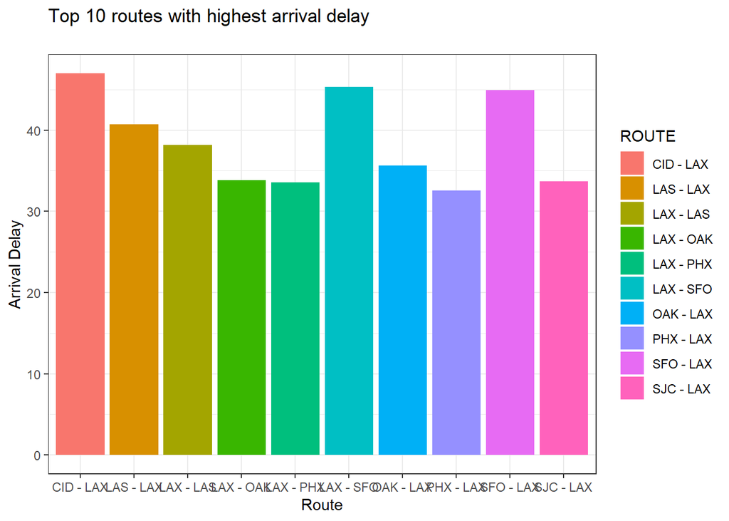

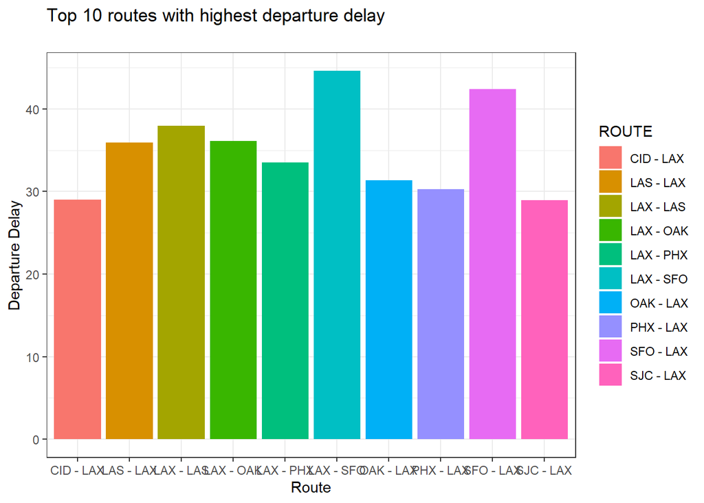

#### We find that 9 of the routes in these top 10 belong to top 20 busy routes.